# Ders

Yogunluk grafikleri, histogramlara göre göze daha hoş görünen grafikler .

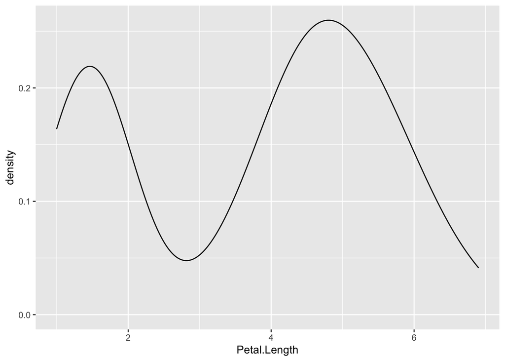

```r
ggplot(data = iris, aes(x = Petal.Length)) + geom_density()
```

Biraz daha güzelleştirelim

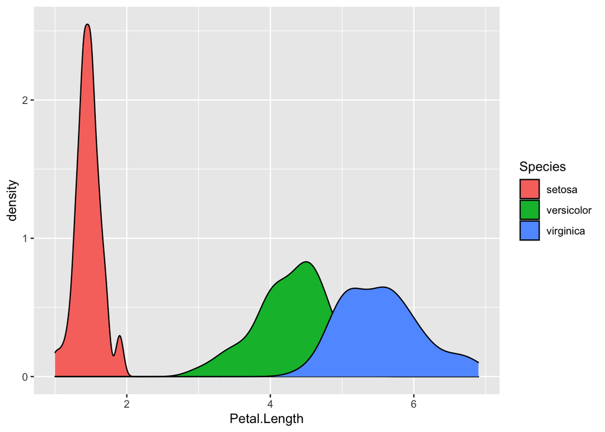

```r
ggplot(data = iris, aes(x = Petal.Length)) + geom_density(aes(fill = Species))
```

Renkleri fill opsiyonu ile verdiğimiz için üç farklı popülasyon içindeki dağılımları vermiş oldu.

Grafiğe transparanlık ekleyelim.

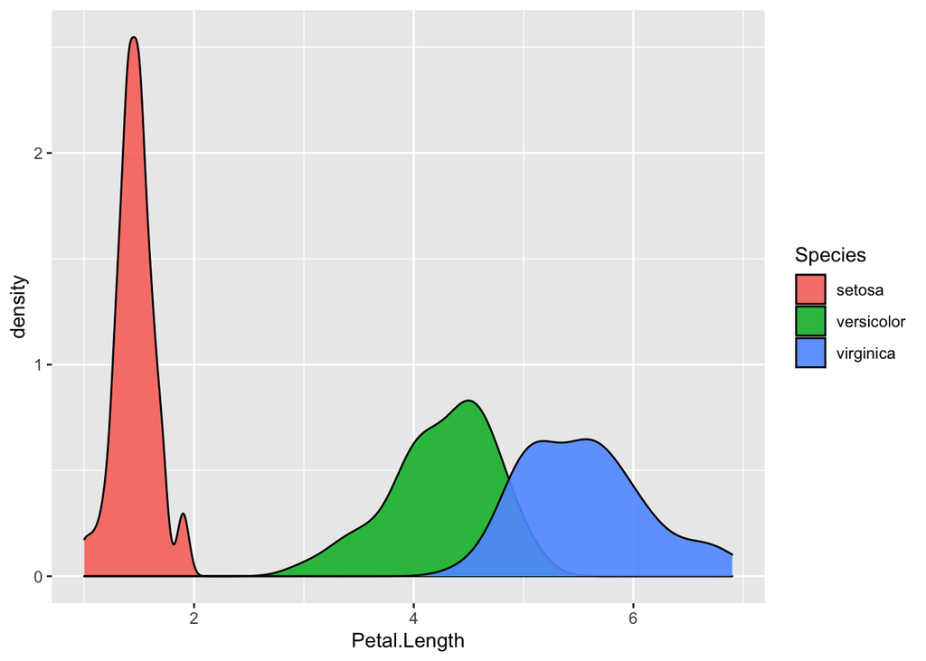

```r
ggplot(data = iris, aes(x = Petal.Length)) + geom_density(aes(fill = Species), alpha = 0.9)
```

Grafiğe isim ekleyelim.

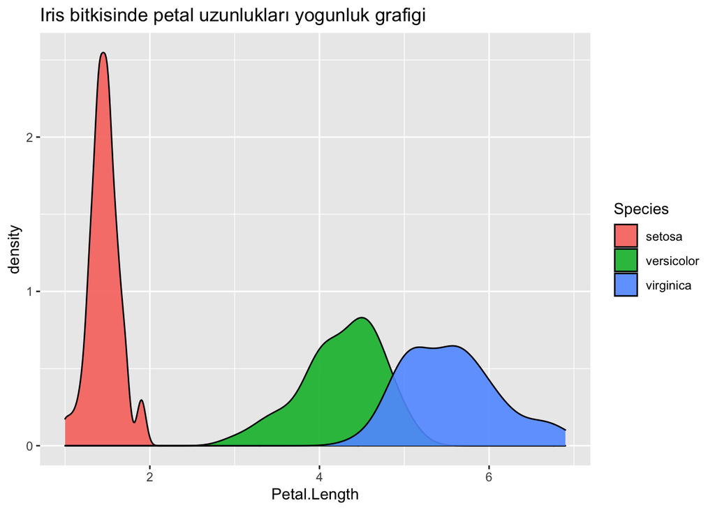

```r
ggplot(data = iris, aes(x = Petal.Length)) + geom_density(aes(fill = Species), alpha = 0.9) + ggtitle(label = "Iris bitkisinde petal uzunlukları yogunluk grafigi")
```

Kutu grafikleri ile ilgili bir grafik. Kutu grafiğine benziyor ama yoğunlukları da vermekte.

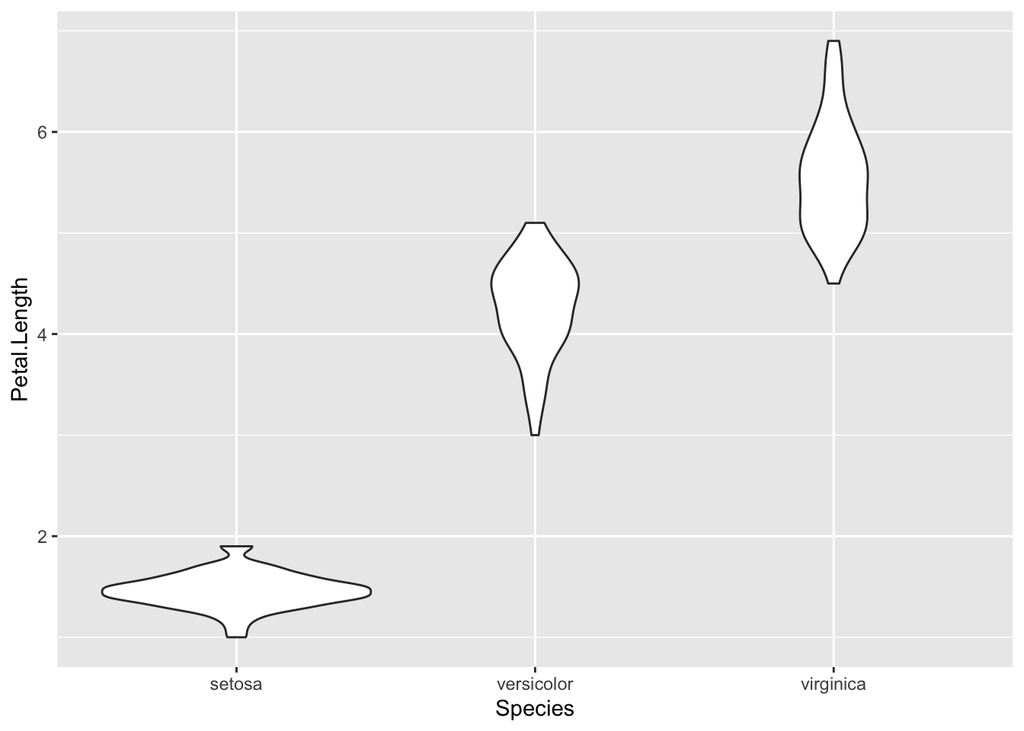

```r
ggplot(data = iris, aes(x = Species, y = Petal.Length)) + geom_violin()
```

Bu grafiği renklendirelim

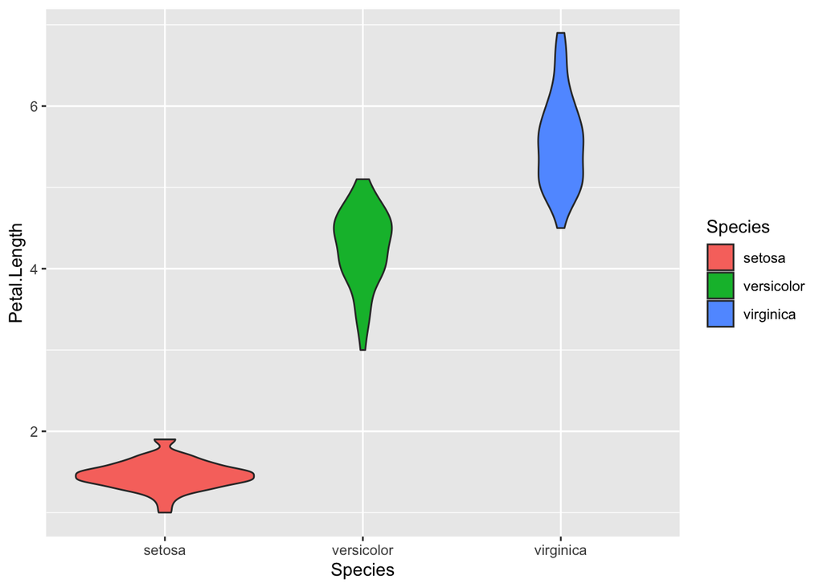

```r
ggplot(data = iris, aes(x = Species, y = Petal.Length)) + geom_violin(aes(fill = Species))
```

Bu grafiğin üstüne farklı görselleştirmeler ekleyebilme imkanımız var.

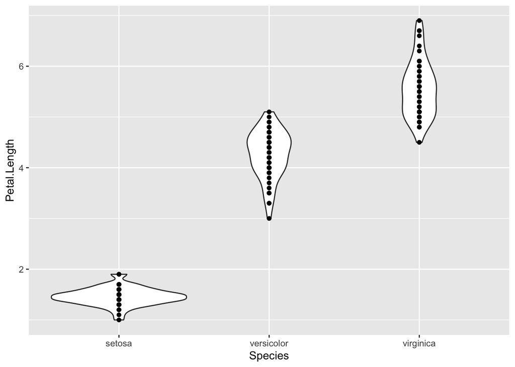

```r
ggplot(data = iris, aes(x = Species, y = Petal.Length)) + geom_violin() + geom_point()
```

geom_jitter fonksiyonu ile de görselleştirme imkanımız var.

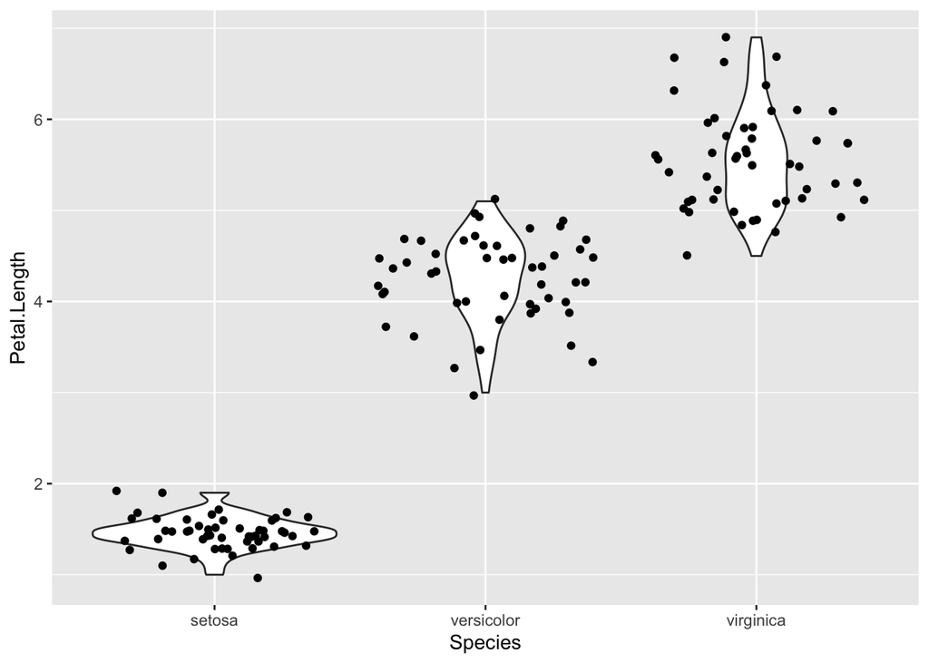

```r
ggplot(data = iris, aes(x = Species, y = Petal.Length)) + geom_violin() + geom_jitter()
```

Noktaların dağılımlarını da ayarlayabiliriz.

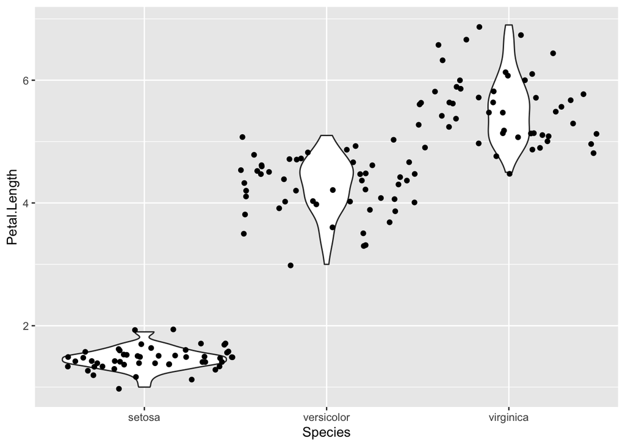

```r
ggplot(data = iris, aes(x = Species, y = Petal.Length)) + geom_violin() + geom_jitter(width = 0.5)
```

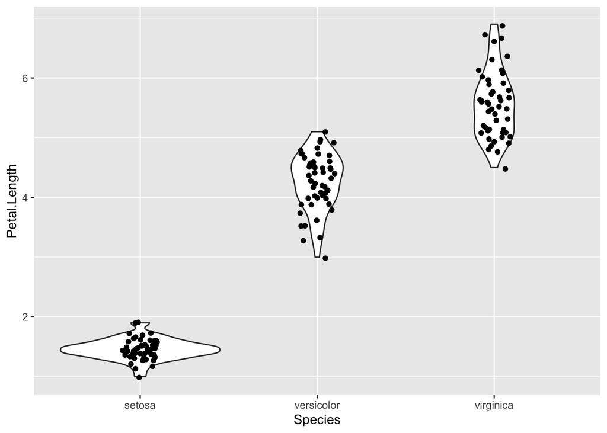

```r
ggplot(data = iris, aes(x = Species, y = Petal.Length)) + geom_violin() + geom_jitter(width = 0.1)
```

Sütun grafikleri oluşturma.

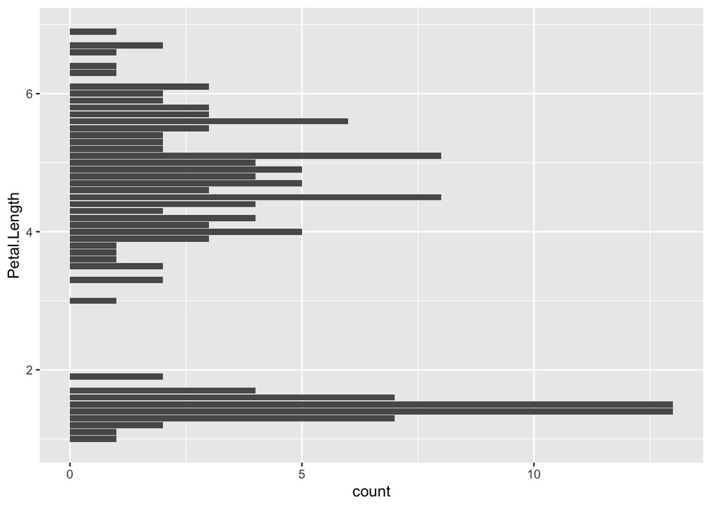

```r
ggplot(data = iris, aes(y = Petal.Length)) + geom_bar()
```

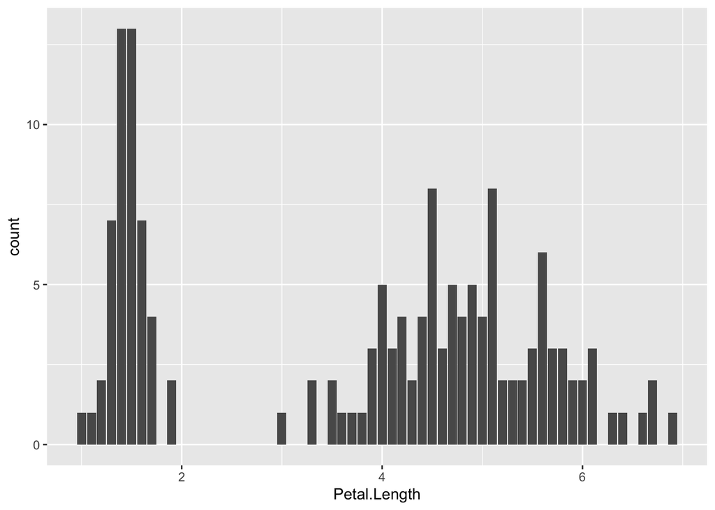

```r
ggplot(data = iris, aes(x = Petal.Length)) + geom_bar()
```